# Inter-ethnic Hostility on Twitter in the Aftermath of Terror Attacks

Lecture to the IGS3 Excellence group at Tel Aviv University

Christian S. Czymara

15 Jan 2023

# Introduction

## Relevance

- Major terror attacks conducted in the name of political Islam in Europe
- Islamist terrorism sometimes blamed on immigration (although generally not true, see Helbling and Meierrieks 2020)
- Perceived discrimination among Muslims increases after Islamist attacks (Giani and Merlino 2020)

## Prior research

- Mixed findings
  - More hostile attitudes after a terror attack (e. g.: Hopkins 2010; Legewie 2013, Böhmelt et al. 2019; Finseraas et al. 2011; Nussio, Bove, and Steele 2019)
  - Little or no effect (e. g.: Brouard et al. 2018; Finseraas, Jakobsson, and Kotsadam 2011; Larsen, Cutts, and Goodwin 2019)
- Young Finns report higher exposure to online hate speech after the Paris 2015 attacks (Kaakinen, Oksanen, and Räsänen 2018)

## Limits of prior research

- Methodological concerns
- Survey data too coarse to measure the time sensitivity of the effects
- Social desirability bias

## Contribution to literature

- Studying effects of terrorist attacks on ethnic hostility in an increasingly important setting
- Research question: *Does ethnic hostility on social media increase after terror attacks?*
- Using Twitter: Time-stamped data capturing naturally occurring behavior

# Theory

## Why are (some) people hostile toward foreigners?

- Individual characteristics (education, socialization, …)
- But also: Context effects
- Group threat theory

## Group threat theory

Blumer (1958): “It is the events seemingly loaded with great collective significance that are the focal points of the public discussion. […] When this public discussion takes the form of a denunciation of the subordinate racial group, signifying that it is unfit and a threat, the discussion becomes particularly potent in shaping the sense of social position” (page 6)

## Group threat theory

- Terrorist attacks pose a threat to individual and collective safety
- Violate social norms
- Cause feelings of anxiety and anger (Vasilopoulos, Marcus, and Foucault)
- And ultimately strengthen intolerance and negative prejudice (Böhmelt, Bove, & Nussio 2019, Hewstones 1989, Jungkunz et al. 2018)

## Hypotheses

- H1: The inter-ethnic insulting increases after Islamist attacks
- H2: The effect of H1 levels off over time
- H3: Individuals post more insulting Tweets after attacks

# Data

## Overview of terror attacks included in analysis

| City | Date | Attack | Deaths | Injuries | Abbreviation |
| --- | --- | --- | --- | --- | --- |
| Paris (FR) | 7–9 January 2015 | Charlie Hebdo + kosher supermarket shootings | 17 | 19 | FR15_CH |
| Paris (FR) | 13 November 2015 | Bataclan shootings and other attacks | 137 | 413 | FR15_BATA |
| Nice (FR) | 14 July 2016 | Bastille Day truck attack | 87 | 270 | FR16 |
| Berlin (DE) | 19 December 2016 | Christmas market truck attack | 13 | 48 | DE16 |
| Barcelona (ES) | 17 August 2017 | Van attacks | 15 | 104 | ES17 |
| Vienna (AT) | 02 November 2020 | Shootings | 5 | 22 | AT20 |

Source: https://www.start.umd.edu/gtd/search/

## Search string

- Goal: Identify Tweets that deal with immigration related topics
- No direct search for terrorism or attacks
- But search should include Muslims (much debated migrant group)
- No direct search for insults or derogatory terms
- Search language specific, English version:

```
 [1] "migration"   "immigration" "migrant"     "immigrant"   "foreigner"
 [6] "migrants"    "immigrants"  "foreigners"  "refugee"     "refugees"
[11] "asylum"      "islam"       "muslim"      "muslims"     "islamist"
[16] "islamism"    "salaﬁst"     "salafism"    "jihad"
```

# Descriptive overview

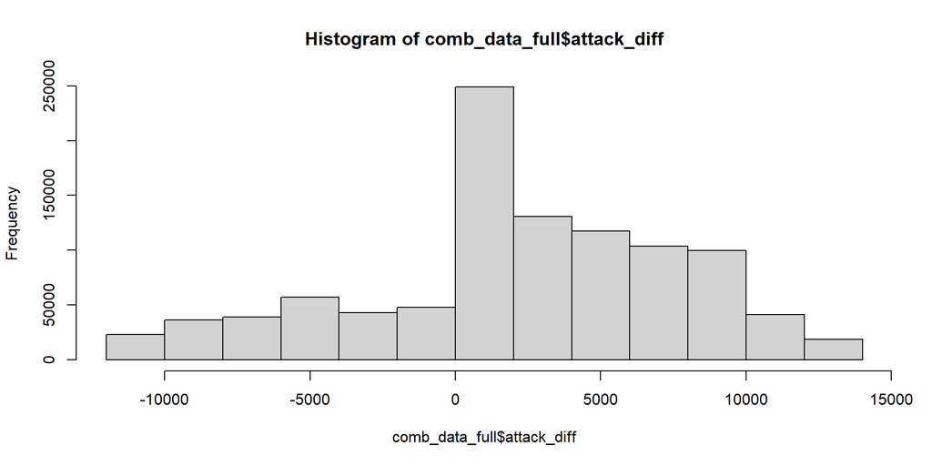

```
                 0      1
  AT20       45627  31130
  DE16       20143  23556
  ES17       71334 197447
  FR15_BATA  43290 170005
  FR15_CH    32669 250054
  FR16       34173  88330
```

```
[1] 1007758
```

## Measuring inter-ethnic hostility

- Relying on of Google Jigsaw’s Conversation AI’s [Perspective](https://perspectiveapi.com/) API
- “Perspective is trained to recognize a variety of attributes (e.g. whether a comment is toxic, threatening, insulting, off-topic, etc.) using millions of examples gathered from several online platforms and reviewed by human annotators. Probability scores represent a probability, with a value between 0 and 1. A higher score indicates a greater likelihood that a reader would perceive the comment as containing the given attribute.” ([Google](https://support.perspectiveapi.com/s/about-the-api-faqs?language=en_US))

## Measuring inter-ethnic hostility

- To measure ethnic hostility, I use the API’s IDENTITY_ATTACK attribute, which should measure “Negative or hateful comments targeting someone because of their identity.” ([Google](https://support.perspectiveapi.com/s/about-the-api-attributes-and-languages?language=en_US))
- In this context, I assume identity proxies ethnicity or race (similar to Czymara et al. 2022)
- Based on convolutional neural networks (Dixon 2018), details of the algorithm are proprietary

# Statistical models

## Differences in insulting before and after attacks (pooled model)

|  | IDENTITY_ATTACK |  |  |
| --- | --- | --- | --- |
| Predictors | Estimates | CI | p |
| (Intercept) | 0.73 | 0.73 – 0.73 | **<0.001** |
| attack befaft01 | 0.07 | 0.07 – 0.07 | **<0.001** |
| case [DE16] | -0.18 | -0.19 – -0.18 | **<0.001** |
| case [ES17] | -0.63 | -0.63 – -0.63 | **<0.001** |
| case [FR15_BATA] | -0.63 | -0.63 – -0.63 | **<0.001** |
| case [FR15_CH] | -0.63 | -0.63 – -0.63 | **<0.001** |
| case [FR16] | -0.60 | -0.61 – -0.60 | **<0.001** |
| Observations | 1007758 |  |  |
| R<sup>2</sup> / R<sup>2</sup> adjusted | 0.517 / 0.517 |  |  |

## Differences in insulting before and after attacks by case (interaction)

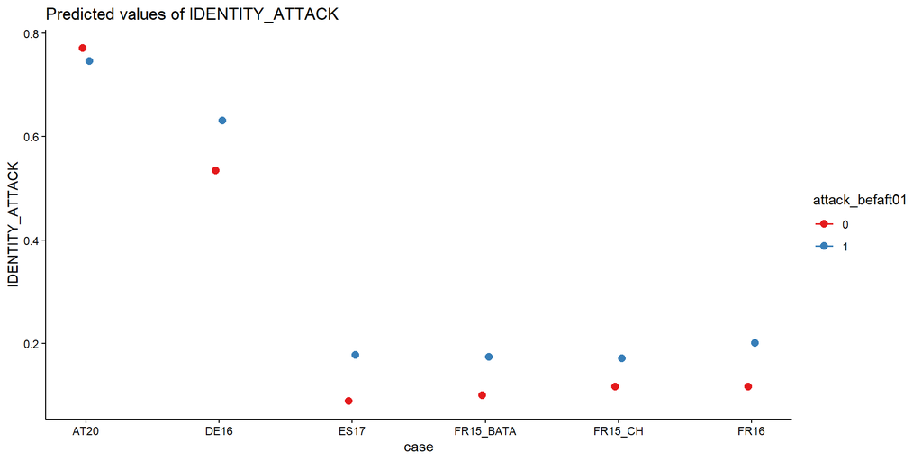

## Differences in trends before and after attacks

- The effect presented so far is a difference in the level before and after
- Are there also differences in the time trends before and after?
- Adding a running variable that counts the time before and after the attack (in *minutes*)
- Second order spline function: $y=\beta_0+\beta_1attack+\beta_2time\_since\_attack+\beta_3attack*time\_since\_attack+\beta_4case+\epsilon$

## Differences in trends before and after attacks

|  | IDENTITY_ATTACK |  |  |
| --- | --- | --- | --- |
| Predictors | Estimates | CI | p |
| (Intercept) | 0.730172 | 0.728500 – 0.731844 | **<0.001** |
| attack diff num | 0.000000 | -0.000000 – 0.000000 | 0.608 |
| attack befaft01 | 0.101962 | 0.100483 – 0.103440 | **<0.001** |
| case [DE16] | -0.182860 | -0.184868 – -0.180852 | **<0.001** |
| case [ES17] | -0.623654 | -0.625051 – -0.622257 | **<0.001** |
| case [FR15_BATA] | -0.625479 | -0.626923 – -0.624035 | **<0.001** |
| case [FR15_CH] | -0.621450 | -0.622869 – -0.620032 | **<0.001** |
| case [FR16] | -0.602584 | -0.604146 – -0.601022 | **<0.001** |
| attack diff num × attack befaft01 | -0.000008 | -0.000008 – -0.000008 | **<0.001** |
| Observations | 1007758 |  |  |
| R<sup>2</sup> / R<sup>2</sup> adjusted | 0.527 / 0.527 |  |  |

## Putting effect size into perspective

```r
# trend by hour
round(tail(m3_full_trend_attack_only$coefficients, 1)*60, 5)
```

```
attack_diff_num:attack_befaft01
                       -0.00047
```

```r
# trend by day
round(tail(m3_full_trend_attack_only$coefficients, 1)*60*24, 3)
```

```
attack_diff_num:attack_befaft01
                         -0.011
```

```r
# after how many days are insult levels back to before attack?
round(-(m3_full_trend_attack_only$coefficients[3]/(tail(m3_full_trend_attack_only$coefficients, 1)*60*24)), 3)
```

```
attack_befaft01
          9.005
```

## Variation in trends across attacks

- Allow both the attack effect and the trends to vary across cases
- Three-way interaction model
- $y=\beta_0+\beta_1attack+\beta_2time\_since\_attack+\beta_3case+...$
- $...\beta_4attack*time\_since\_attack*case+\epsilon$

## Variation in trends across attacks

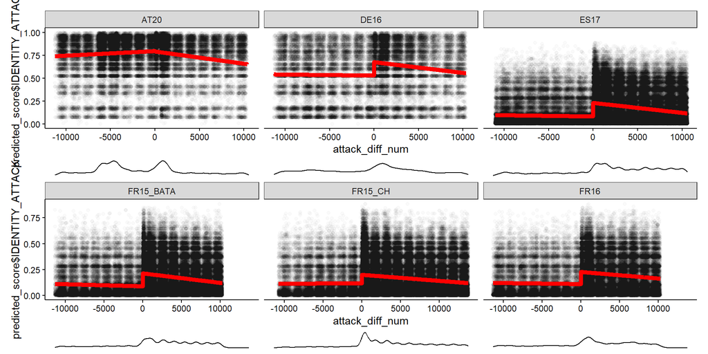

## What’s happening in the case of the Austria attack?

- Randome sample of Tweets from the day *before* the attack:

```
 [1] "@HasnainKazim Herrlich \nWenn das Migration ist, was ist dann MUC -&gt; BO?"
 [2] "Um Argumente, warum eine Abschiebung nicht vollzogen werden kann, ist unsere Regierung nie verlegen. Das dabei auch gefährliche Islamisten und kriminelle darunter sind wird einfach hingenommen. \n\nhttps://t.co/upUjJmADUw"
 [3] "Zum Glück haben uns die Intelligenzbestien der @tazgezwitscher uns gestern noch erzählt, dass Macron den islamischen Mord an dem Lehrer aufgebauscht hätte. Der Krieg ist in Europa angekommen!....#nizza #Islam #Islamismus #Frankreich #Kirche  https://t.co/TnamBlR9WP"
 [4] "@tagesthemen @tagesschau @EEhni Wer hier Öl ins Feuer gießt ist für viele Muslime klar aber ihr versucht selbst den Terror in Frankreich mit der Türkei zu verbinden!\n\nNein! Das was @EmmanuelMacron sagte und machte ist nicht Meinungsfreiheit!\n\nEs ist Rassismus und Diskriminierung von oberst…
 [5] "@Blocher_Perlen \"Wir sollten wieder vermehrt über Ausländer diskutieren. Das löst das Corona- und das Klimaproblem gleichermassen\"."
 [6] "@normalguy333 @ww_muc @Hasencrowd @Birgit_Kelle Eine Reformation in dem man billigt das Satire Zeichnungen sich sogar über Genozide lustig machen dürfen und sowas als Meinungsfreiheit abgestempelt wird...\nDas was diese Zeitung macht bzw. Wie macron medial gegen Muslime vorgeht ist weit mehr a…
 [7] "@UmairZ90 @Netzdenunziant @PresseAhmadiyya Die Ahmadiyya sind eine winzige Splittergruppe, die von den meisten anderen Moslems noch nicht mal als Moslems anerkannt werden. Daher ist dieses Statement in der Tat recht sinnlos. Insbesondere auch, weil die Ahmadiyya eh nix mit Terror am Hut haben.…
 [8] "Bei kaltem Wetter scheinen sich nicht nur biologische Viren wie Corona besser verbreiten zu können, auch mentale Viren wie der radikale Islam scheinen bei kühleren Temperaturen effektiver zu gedeihen. #halsabschneideritis #Nizza"
 [9] "der Islam wird wieder und wieder als Schutzschild missbraucht um unmenschliche cruel crimes zu rechtfertigen &amp; in den USA wird HusoTrump von der christlichen Extreme supportet - wenn man man keiner Kirche/Religion angehört, ist das schon ein Akt der Gnade an der Menschheit??"
[10] "@Tile03277565 @IliasUyar @Reser4t Nationalismus ist nicht mit dem Islam konform. Solche Zustände sich nicht der Auswuchs des Islams, sondern faschistische Auswüchse."
```

- Another attack: [Nice stabbing](https://en.wikipedia.org/wiki/2020_Nice_stabbing) on 29 October 2020

## Examining intra-individual change in Tweeting behavior

- Analyzing a subset of accounts that Tweeted at least once before *and* after an attack
- Benefit: Testing differences within units over time
- Automatically controlling for unobserved heterogeneity
- But somewhat different sample
- Fixed effects model: $\ddot{y}_{it}=\ddot{\beta}_1attack+\ddot{\beta}_2case+\ddot{\epsilon}_{it}$

## Intra-individual change in Tweeting behavior

[output not shown]

## Intra-individual change change by case (interaction attack X case)

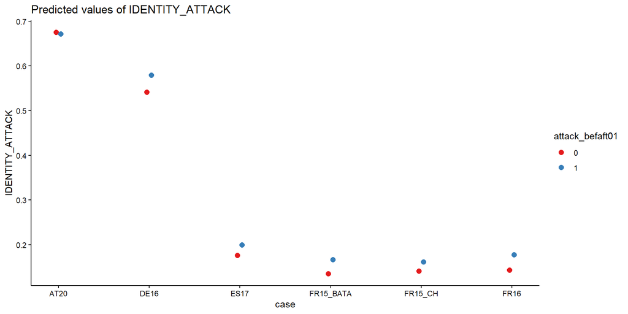

## Limitations

- Generalization of findings?
- Deletion of hate speech (results thus overly conservative)
- Online and offline behavior comparable?
- Classification based on machine learning is a black box

## Next steps

- Validating predictor (i.e. handcoding some Tweets)
- Download more attacks
- Maybe: Examing likes or retweets
- ?